# R Notebook: Random Forests

`r`r library(randomForest)

`r`r library(MASS) library(ISLR)

Working with Boston data: Finding the dimensions of Boston data

`r`r dim(Boston)

```
[1] 506  14
```

Boston has 14 variables including Response variable

`r`r head(Boston)

|  | crim | zn | indus | chas | nox | rm | age | dis | rad | tax | ptratio | black | lstat | medv |
| --- | --- | --- | --- | --- | --- | --- | --- | --- | --- | --- | --- | --- | --- | --- |
| 1 | 0.00632 | 18 | 2.31 | 0 | 0.538 | 6.575 | 65.2 | 4.0900 | 1 | 296 | 15.3 | 396.90 | 4.98 | 24.0 |
| 2 | 0.02731 | 0 | 7.07 | 0 | 0.469 | 6.421 | 78.9 | 4.9671 | 2 | 242 | 17.8 | 396.90 | 9.14 | 21.6 |
| 3 | 0.02729 | 0 | 7.07 | 0 | 0.469 | 7.185 | 61.1 | 4.9671 | 2 | 242 | 17.8 | 392.83 | 4.03 | 34.7 |
| 4 | 0.03237 | 0 | 2.18 | 0 | 0.458 | 6.998 | 45.8 | 6.0622 | 3 | 222 | 18.7 | 394.63 | 2.94 | 33.4 |
| 5 | 0.06905 | 0 | 2.18 | 0 | 0.458 | 7.147 | 54.2 | 6.0622 | 3 | 222 | 18.7 | 396.90 | 5.33 | 36.2 |
| 6 | 0.02985 | 0 | 2.18 | 0 | 0.458 | 6.430 | 58.7 | 6.0622 | 3 | 222 | 18.7 | 394.12 | 5.21 | 28.7 |

Creating training and test sample. But, first we need to set the seed to get correct random sample

`r`r set.seed(1) train = sample(1:nrow(Boston),nrow(Boston)/2) test = (-train)

Now, we have to fit random forest model on train Boston data. First we start with Bagging. As Bagging is a special case of random forest in which m = no of variables in data therefore, we use random forest with mtry = 13 (all variables will be considered at each split in the tree) and importance = TRUE, which asks the model to access the importance of variables.

`r`r bagging.boston = randomForest(medv ~ ., data = Boston,subset = train, mtry = 13, importance = TRUE) bagging.boston

```
Call:
 randomForest(formula = medv ~ ., data = Boston, mtry = 13, importance = TRUE,      subset = train)
               Type of random forest: regression
                     Number of trees: 500
No. of variables tried at each split: 13

          Mean of squared residuals: 11.02164
                    % Var explained: 86.65
```

Predict the data using predict function

[figure not shown]

We can see from the graph that predictions from bagging are somewhere close to test data of Boston. We can find the mean error to predict the accuracy

`r`r mean((pred.Boston - Boston[test,‘medv’])^2)

```
[1] 13.2969
```

We can change number of trees grown by random forest (ie B bagged trees). Here, we have set ntree = 25

`r`r bagging.boston = randomForest(medv ~ ., data = Boston,subset = train, mtry = 13, ntree = 25) pred.Boston = predict(bagging.boston, newdata = Boston[test,]) mean((pred.Boston - Boston[test,‘medv’])^2)

```
[1] 13.91727
```

Random Forest works better than bagging because at each split it chooses m variables, where m<p. Thus, there will be trees that are not correlated with each other as we can observe in Bagging that there will always be one predictor which is strong and get chosen at the root level for every tree. Therefore, most of the bagged trees will be correlated, unlike random forest, and average variance will be more. In case of Random Forest, average variance will be less because no of trees which are correlated will be less. Generally, randomForest() takes m = p/3. Here we are taking m = 4

`r`r rf.boston = randomForest(medv ~ ., data = Boston,subset = train, mtry = 4, importance = TRUE) pred.Boston = predict(bagging.boston, newdata = Boston[test,]) mean((pred.Boston - Boston[test,‘medv’])^2)

[output not shown]

`r`r importance(rf.boston)

```
           %IncMSE IncNodePurity
crim    13.1990165    1263.39964
zn       4.5418947     101.20804
indus   11.1084961    1383.43161
chas     0.6685081      86.28016
nox     13.2750828    1357.02337
rm      30.2540388    5524.17545
age      9.5743816     707.46528
dis     13.1482971    1373.80831
rad      4.5683498     130.96081
tax      9.1789626     674.05856
ptratio 11.3450187    1286.16772
black    8.3830623     446.34429
lstat   24.3711815    6132.57739
```

%IncMSE shows decrease in accuracy if that variable is not included in the model. IncNodePurity shows average increase in nodePurity over all trees in random forests when including that variable in split. Otherway, the former is based upon the mean decrease of accuracy in predictions on the out of bag samples when a given variable is excluded from the model. The latter is a measure of the total decrease in node impurity that results from splits over that variable, averaged over all trees. In the case of regression trees, the node impurity is measured by the training RSS, and for classification trees by the deviance.

`r`r varImpPlot(rf.boston)

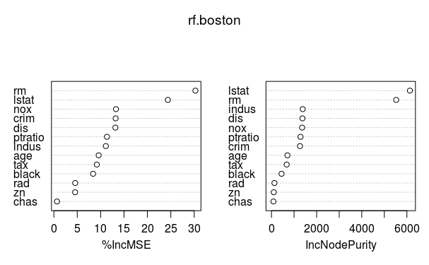